# Linear Regression Models: Multiple Linear Regression

## Polynomial Regression

- Simple linear regression model can be extended in many ways…
- Can include *higher order terms*

\[Y_i = \beta_0 + \beta_1x_i + \beta_2x_i^2+E_i\]

- Still use `lm()`
  - add "main effect" higher order terms with `I(var^k)`
  - can use `poly(var, degree, raw = TRUE)`
  - without `raw = TRUE` centered variables are used

```r
quadFit <- lm(dist ~ speed + I(speed^2), cars)
```

## Polynomial Regression

```r
quadFit <- lm(dist ~ speed + I(speed^2), cars)
quadFit
```

```
##
## Call:
## lm(formula = dist ~ speed + I(speed^2), data = cars)
##
## Coefficients:
## (Intercept)        speed   I(speed^2)
##     2.47014      0.91329      0.09996
```

## Polynomial Regression

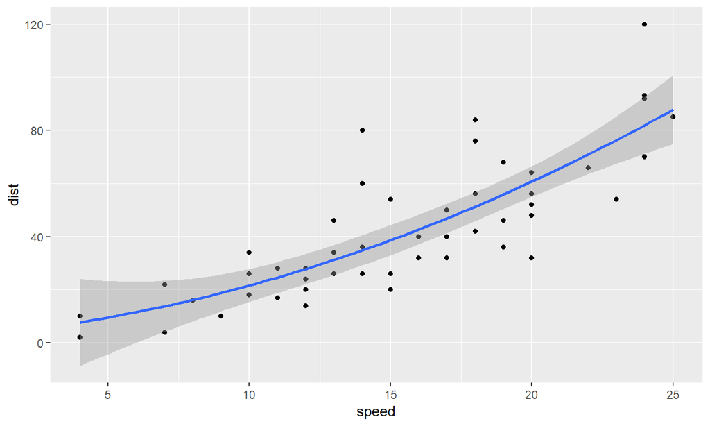

```r
ggplot(cars, aes(x = speed, y = dist)) + geom_point() +
    geom_smooth(method = "lm", formula = y ~ x + I(x^2))
```

## Polynomial Regression

- Prediction can still be done with `predict()`

```r
predict(quadFit, newdata = data.frame(speed = c(4, 25)), interval = "confidence")
```

```
##         fit       lwr      upr
## 1  7.722637 -8.665329  24.1106
## 2 87.776892 74.782756 100.7710
```

## Polynomial Regression

- Add PI easily added with `ciTools`

[figure not shown]

```r
cars <- datasets::cars %>% ciTools::add_pi(quadFit, names = c("lower", "upper"))
ggplot(cars, aes(x = speed, y = dist)) +
    geom_point() +
    geom_smooth(method = "lm", formula = y ~ x + I(x^2), fill = "Blue") +
    geom_ribbon(aes(ymin = lower, ymax = upper), alpha = 0.3, fill = "Red") +
    ggtitle("Scatter Plot with 95% PI")
```

## Multiple Linear Regression

- Simple linear regression model can be extended in many ways…
- Can include more *explanatory variables* and/or *higher order terms*

Ex:

\[Y_i = \beta_0 + \beta_1x_{1i} + \beta_2x_{2i} + \beta_3x_{1i}x_{2i}+E_i\]

- Still use `lm()`
  - add "main effect" terms with `+ name`
  - interactions with `+ name1:name2`
  - all possible combinations with `+ name1*name2`
- Still fit by minimizing sum of squared errors

## Multiple Linear Regression

- Consider data on voting preferences by county
  - Use pct with college degree & population change in county to predict county level income

```r
voting <- tbl_df(read.csv("../datasets/counties.csv", header = TRUE))
subVoting <- voting %>% select(college, pop.change, income)
subVoting
```

```
## # A tibble: 3,141 x 3
##   college pop.change income
##     <dbl>      <dbl>  <int>
## 1   14.5       11.9   32240
## 2   16.8       35.4   30199
## 3   11.8        2     23838
## 4    4.70       9.20  23714
## 5    7         10.6   26323
## # ... with 3,136 more rows
```

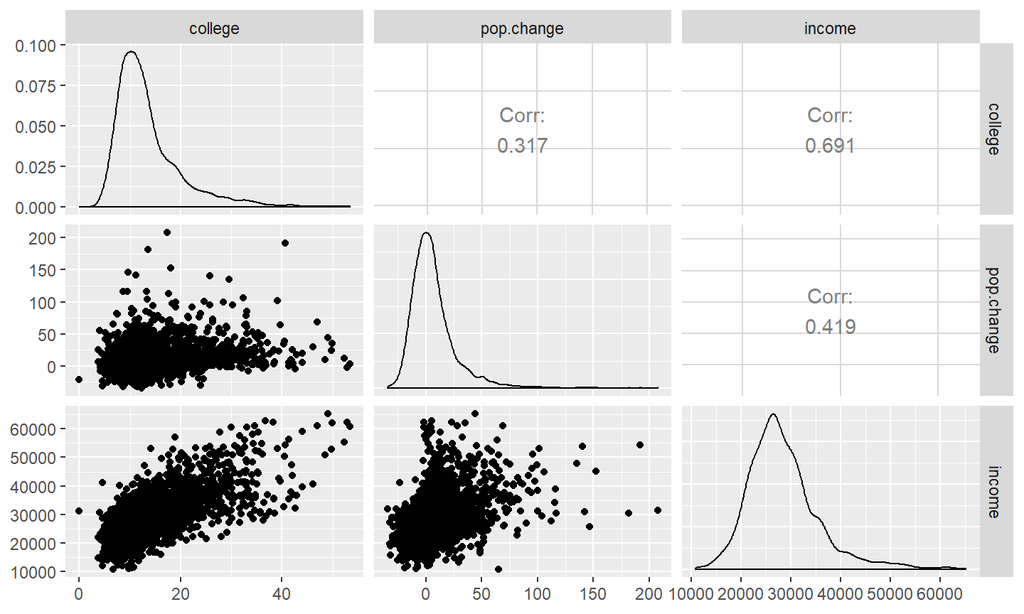

```r
GGally::ggpairs(subVoting)
```

## Multiple Linear Regression

```r
plot3d(x = subVoting$pop.change, y = subVoting$college, z = subVoting$income,
             xlab = "Pop Change", ylab = "Per College", zlab = "Income")
```

[interactive chart not shown]

## Multiple Linear Regression

- Fit "best" plane through points

\[E(Income) = \beta_0 + \beta_1*(Per College) + \beta_2*(Pop Change)\]

- Fit "best" saddle through the points

\[E(Income) = \beta_0 + \beta_1*(Per College) +\] \[ \beta_2*(Pop Change) + \beta_3*(Per Income)*(Pop Change)\]

## Multiple Linear Regression

```r
fit <- lm(income ~ pop.change + college, data = subVoting)
#set up prediction explanatory variables
grid.lines = 40
x.pred <- seq(min(subVoting$pop.change), max(subVoting$pop.change), length.out = grid.lines)
y.pred <- seq(min(subVoting$college), max(subVoting$college), length.out = grid.lines)
xy <- expand.grid(pop.change = x.pred, college = y.pred)
#predictions
z.pred <- matrix(predict(fit, newdata = xy),
                                 nrow = grid.lines, ncol = grid.lines)
# scatter plot with regression plane (rgl package)
plot3d(x = subVoting$pop.change, y = subVoting$college, z = subVoting$income,
                    cex = 0.8, theta = 20, phi = 20, ticktype = "detailed",
                    xlab = "Pop Change", ylab = "Per College", zlab =
"Income")
#add surface
surface3d(x = x.pred, y = y.pred, z = z.pred, color = "green")
```

[interactive chart not shown]

## With an Interaction Term

[interactive chart not shown]

## With an Interaction Term and Quadratic Terms

[interactive chart not shown]

## With an Interaction Term and Quadratic Terms

```r
fit <- lm(income ~ pop.change + college + pop.change:college +
                        I(pop.change^2) + I(college^2), data = subVoting)
x.pred <- seq(min(subVoting$pop.change), max(subVoting$pop.change), length.out = 3)
y.pred <- seq(min(subVoting$college), max(subVoting$college), length.out = 3)

data.frame(x.pred, y.pred)
```

```
##   x.pred y.pred
## 1 -34.40    0.0
## 2  86.65   26.7
## 3 207.70   53.4
```

## With an Interaction Term and Quadratic Terms

```r
xy <- expand.grid(pop.change = x.pred, college = y.pred)
data.frame(xy, predict(fit, newdata = xy))
```

```
##   pop.change college predict.fit..newdata...xy.
## 1     -34.40     0.0                   14181.15
## 2      86.65     0.0                   21706.75
## 3     207.70     0.0                   14835.10
## 4     -34.40    26.7                   31859.87
## 5      86.65    26.7                   43578.22
## 6     207.70    26.7                   40899.30
## 7     -34.40    53.4                   42878.38
## 8      86.65    53.4                   58789.46
## 9     207.70    53.4                   60303.30
```

## Including a Categorical Predictor

- May want fits that differ by the level of a variable
- Could do separate SLR for each region setting

```r
ggplot(voting, aes(x = college, y = income)) + geom_point(aes(col = region)) +
  geom_smooth(method = "lm", aes(col = region))
```

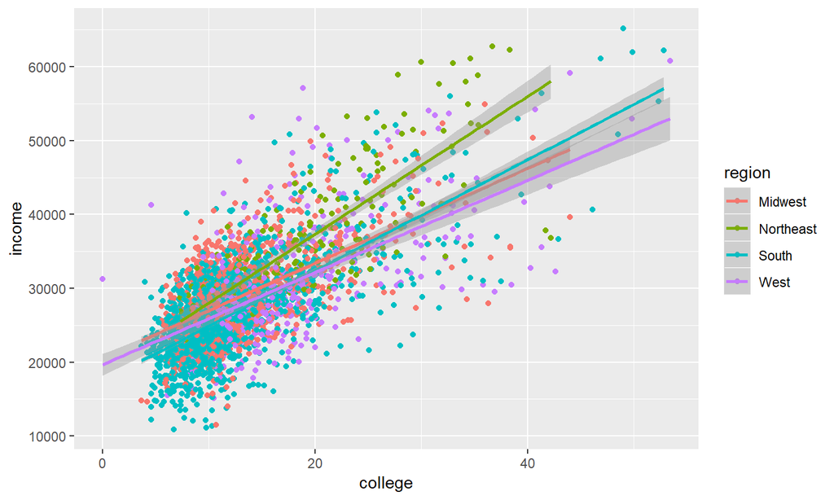

```r
ggplot(voting, aes(x = college, y = income)) + geom_point(aes(col = region)) +
  geom_smooth(method = "lm", aes(col = region))
```

## Including a Categorical Predictor

- May want fits that differ by the level of a variable
- Often better to do in one model fit
- Here a common slope is assumed
- R uses the first level of the categorical variable as a reference level

```r
regionFit <- lm(income ~ college + region, data = voting)
regionFit
```

```
##
## Call:
## lm(formula = income ~ college + region, data = voting)
##
## Coefficients:
##     (Intercept)          college  regionNortheast      regionSouth
##         19584.1            718.6           3100.9          -1801.1
##      regionWest
##         -1529.4
```

## Including a Categorical Predictor

- Interpreting model fit

```r
levels(voting$region)
```

```
## [1] "Midwest"   "Northeast" "South"     "West"
```

```r
coef(regionFit)
```

```
##     (Intercept)         college regionNortheast     regionSouth
##      19584.1047        718.6427       3100.9491      -1801.0579
##      regionWest
##      -1529.4278
```

- Intercept really represents estimated average income for Midwest with 0 percent college

## Including a Categorical Predictor

- Intercept really represents estimated average income for Midwest with 0 percent college

\[Est~Midwest~Income = 19584.1 + 718.6*(Per College)\]

- If you want to predict for the Northeast, include that coefficient in the intercept

\[Est~Northeast~Income = 19584.1 +3100.9 + 718.6*(Per College)\]

## Including a Categorical Predictor

- Perhaps a different slope and different intercept for each group
- Same idea, college coefficient represents slope for Midwest

```r
fullRegionFit <- lm(income ~ college*region, data = voting)
fullRegionFit
```

```
##
## Call:
## lm(formula = income ~ college * region, data = voting)
##
## Coefficients:
##             (Intercept)                  college          regionNortheast
##                20566.12                   642.18                 -1864.03
##             regionSouth               regionWest  college:regionNortheast
##                -3164.12                  -903.73                   289.96
##     college:regionSouth       college:regionWest
##                  107.84                   -18.18
```

## Compare Different Fits (Midwest)

\[Est~Midwest~Income = 20566.12 + 642.18*(Per College)\]

```r
summary(regionFit)$sigma #Estimated standard deviation (pools across groups)
```

```
## [1] 5011.809
```

```r
fits <- voting %>% group_by(region) %>% do(model = lm(income ~ college, data = .))
coef(fits$model[[1]])
```

```
## (Intercept)     college
##  20566.1225    642.1824
```

```r
summary(fits$model[[1]])$sigma #doesn't pool across groups
```

```
## [1] 4668.552
```